# cTWAS report

Darren Cameron

2026-01-29

## cTWAS pipeline steps

1. `create_ld_matrices`: Create (1000G hg38 build) LD matrices and variant info files for cTWAS
2. `copy_fusion_weights`: Copy genuine FUSION weight files (cTWAS chokes if any empty files are in weight dir)
3. `run_ctwas`: Run cTWAS on sc-eQTL and GWAS data
4. `run_ctwas_multi`: Run multi-group cTWAS all cell types per GWAS
5. `ctwas_report`: Generate cTWAS report

TODO:

1. Just showing multi for now. Can add individual runs again later
2. Add gene / region for plot(s) for interesting genes

### Correction

Table 1. cTWAS-testable genes per cell type

Defined in FUSION compute weights step, cis-heritability (hsq_p < 0.01)

| Cell type | Genes tested in TWAS |
| --- | --- |
| Glu-UL | 1680 |
| Glu-DL | 1345 |
| GABA | 1279 |
| NPC | 1250 |
| Glu-UL-0 | 1220 |
| Glu-UL-2 | 1077 |
| Glu-UL-1 | 852 |
| GABA-1 | 839 |
| Glu-DL-0 | 776 |
| NPC-1 | 747 |
| GABA-0 | 701 |
| Glu-DL-1 | 700 |
| Glu-DL-2 | 666 |
| NPC-0 | 617 |
| NPC-2 | 446 |
| OPC | 440 |
| Endo-Peri | 418 |
| GABA-2 | 382 |
| MG | 373 |
| Unique across all cell types | 5654 |

Genes were included if FUSION produced a non-empty weight file, indicating sig. cis-heritability (hsq_p < 0.01). The final row reports the union of genes across all cell types and defines BF correction factor for cTWAS analyses.

### Multi

#### Z-scores

##### SCZ

**SCZ**

cTWAS significant genes (P<sub>BF</sub> < 0.05): **159**

| Cell Type | Gene Symbol | ENSG ID | Z-score | P-value | BF(P) | FDR | Gene Type | Chr |
| --- | --- | --- | --- | --- | --- | --- | --- | --- |
| GABA-1 | ZSCAN26 | ENSG00000197062 | 13.82 | 2e-43 | 1.1e-39 | 3.2e-39 | protein_coding | 6 |
| Glu-DL | ZKSCAN8 | ENSG00000198315 | -13.16 | 1.5e-39 | 8.5e-36 | 8e-36 | protein_coding | 6 |
| Glu-UL-1 | HMGN4 | ENSG00000182952 | 12.99 | 1.3e-38 | 7.4e-35 | 5.3e-35 | protein_coding | 6 |
| NPC | NA | ENSG00000310474 | -10.08 | 6.7e-24 | 3.8e-20 | 1.2e-20 | lncRNA | 6 |
| Glu-UL-0 | ZSCAN23 | ENSG00000187987 | -9.74 | 2.1e-22 | 1.2e-18 | 3.3e-19 | protein_coding | 6 |
| Glu-DL-0 | H3C4 | ENSG00000197409 | 9.47 | 2.9e-21 | 1.6e-17 | 4.3e-18 | protein_coding | 6 |
| Glu-UL-0 | LINC03003 | ENSG00000290496 | 9.43 | 4.2e-21 | 2.4e-17 | 5.6e-18 | lncRNA | 6 |
| Glu-UL-0 | DXO | ENSG00000204348 | 9.15 | 5.7e-20 | 3.2e-16 | 6.1e-17 | protein_coding | 6 |
| Glu-UL | MSH5 | ENSG00000204410 | 9.03 | 1.8e-19 | 1e-15 | 1.8e-16 | protein_coding | 6 |
| GABA-0 | VWA7 | ENSG00000204396 | -9 | 2.3e-19 | 1.3e-15 | 2.1e-16 | protein_coding | 6 |
| NPC | H3C12 | ENSG00000197153 | 8.57 | 1e-17 | 5.9e-14 | 8e-15 | protein_coding | 6 |
| NPC-0 | NA | ENSG00000290870 | 8.45 | 2.9e-17 | 1.6e-13 | 1.9e-14 | lncRNA | 6 |
| Glu-UL-0 | BTN3A1 | ENSG00000026950 | -8.23 | 1.9e-16 | 1.1e-12 | 1.2e-13 | protein_coding | 6 |
| GABA-1 | ARL3 | ENSG00000138175 | -8.16 | 3.5e-16 | 2e-12 | 2.1e-13 | protein_coding | 10 |
| NPC | NA | ENSG00000291112 | -8.09 | 5.8e-16 | 3.3e-12 | 3.3e-13 | lncRNA | 6 |
| NPC | BTN3A2 | ENSG00000186470 | 8.07 | 7.2e-16 | 4.1e-12 | 4e-13 | protein_coding | 6 |
| Glu-UL | ZNF391 | ENSG00000124613 | -8.01 | 1.2e-15 | 6.7e-12 | 6.2e-13 | protein_coding | 6 |
| Glu-UL-1 | NA | ENSG00000302043 | 7.91 | 2.5e-15 | 1.4e-11 | 1.3e-12 | lncRNA | 6 |
| NPC | AS3MT | ENSG00000214435 | 7.85 | 4.3e-15 | 2.4e-11 | 2e-12 | protein_coding | 10 |
| MG | PPP1R10 | ENSG00000204569 | 7.72 | 1.1e-14 | 6.5e-11 | 5e-12 | protein_coding | 6 |
| Glu-DL | INO80E | ENSG00000169592 | 7.52 | 5.3e-14 | 3e-10 | 2.1e-11 | protein_coding | 16 |
| NPC-1 | NA | ENSG00000281538 | 7.33 | 2.3e-13 | 1.3e-09 | 8.6e-11 | lncRNA | 22 |
| GABA-2 | H2BC11 | ENSG00000124635 | -7.31 | 2.6e-13 | 1.5e-09 | 9.6e-11 | protein_coding | 6 |
| Glu-DL | INA | ENSG00000148798 | -7.19 | 6.7e-13 | 3.8e-09 | 2.1e-10 | protein_coding | 10 |
| Glu-DL | WBP2NL | ENSG00000183066 | 7.13 | 9.9e-13 | 5.6e-09 | 3e-10 | protein_coding | 22 |
| Glu-UL-2 | MARK3 | ENSG00000075413 | -7.12 | 1.1e-12 | 6e-09 | 3.1e-10 | protein_coding | 14 |
| Glu-DL | SF3B1 | ENSG00000115524 | 7.07 | 1.6e-12 | 9.1e-09 | 4.6e-10 | protein_coding | 2 |
| GABA-0 | ST3GAL3 | ENSG00000126091 | 7.06 | 1.7e-12 | 9.6e-09 | 4.7e-10 | protein_coding | 1 |
| NPC-1 | NA | ENSG00000285902 | -7 | 2.5e-12 | 1.4e-08 | 6.6e-10 | lncRNA | 13 |
| GABA | LINC00382 | ENSG00000229175 | -6.84 | 7.9e-12 | 4.5e-08 | 1.9e-09 | lncRNA | 13 |

[output cut: 129 more lines]

##### BPD

**BPD**

cTWAS significant genes (P<sub>BF</sub> < 0.05): **45**

| Cell Type | Gene Symbol | ENSG ID | Z-score | P-value | BF(P) | FDR | Gene Type | Chr |
| --- | --- | --- | --- | --- | --- | --- | --- | --- |
| Glu-UL-1 | HMGN4 | ENSG00000182952 | 8.34 | 7.5e-17 | 4.2e-13 | 1.2e-12 | protein_coding | 6 |
| GABA | NA | ENSG00000259683 | -7.26 | 4e-13 | 2.3e-09 | 3.1e-09 | pseudogene | 15 |
| GABA-0 | NA | ENSG00000285902 | -6.6 | 4.1e-11 | 2.3e-07 | 7.8e-08 | lncRNA | 13 |
| GABA-1 | ZSCAN26 | ENSG00000197062 | 6.33 | 2.5e-10 | 1.4e-06 | 2.9e-07 | protein_coding | 6 |
| NPC | NA | ENSG00000291210 | -6.15 | 7.7e-10 | 4.3e-06 | 7.1e-07 | lncRNA | 15 |
| Glu-DL | LINC00382 | ENSG00000229175 | -6.13 | 9e-10 | 5.1e-06 | 7.8e-07 | lncRNA | 13 |
| GABA-0 | NA | ENSG00000307098 | -6.02 | 1.8e-09 | 1e-05 | 1.4e-06 | lncRNA | 11 |
| Glu-UL | GOLGA6L5P | ENSG00000230373 | 6 | 2e-09 | 1.1e-05 | 1.5e-06 | pseudogene | 15 |
| Glu-DL | INO80E | ENSG00000169592 | 5.7 | 1.2e-08 | 6.9e-05 | 6e-06 | protein_coding | 16 |
| Glu-UL-1 | ZKSCAN8 | ENSG00000198315 | -5.57 | 2.5e-08 | 0.00014 | 1.1e-05 | protein_coding | 6 |
| Glu-UL | MSH5 | ENSG00000204410 | 5.5 | 3.8e-08 | 0.00022 | 1.6e-05 | protein_coding | 6 |
| GABA | PACS1 | ENSG00000175115 | 5.48 | 4.2e-08 | 0.00024 | 1.7e-05 | protein_coding | 11 |
| GABA-0 | SNX16 | ENSG00000104497 | 5.44 | 5.3e-08 | 3e-04 | 1.9e-05 | protein_coding | 8 |
| Glu-DL-0 | H3C4 | ENSG00000197409 | 5.35 | 8.6e-08 | 0.00049 | 2.8e-05 | protein_coding | 6 |
| GABA | ADD3 | ENSG00000148700 | 5.35 | 8.6e-08 | 0.00049 | 2.8e-05 | protein_coding | 10 |
| NPC | BTN3A2 | ENSG00000186470 | 5.32 | 1e-07 | 0.00058 | 3.3e-05 | protein_coding | 6 |
| Glu-DL | PLEC | ENSG00000178209 | -5.3 | 1.1e-07 | 0.00064 | 3.6e-05 | protein_coding | 8 |
| Glu-DL | SF3B1 | ENSG00000115524 | 5.27 | 1.4e-07 | 0.00077 | 4e-05 | protein_coding | 2 |
| GABA-0 | ST3GAL3 | ENSG00000126091 | 5.25 | 1.5e-07 | 0.00084 | 4.3e-05 | protein_coding | 1 |
| NPC-0 | NA | ENSG00000293612 | 5.1 | 3.3e-07 | 0.0019 | 9.3e-05 | lncRNA | 2 |
| Glu-UL | NA | ENSG00000299747 | 5.08 | 3.7e-07 | 0.0021 | 1e-04 | lncRNA | 6 |
| Glu-UL-2 | ARL3 | ENSG00000138175 | -5.07 | 4e-07 | 0.0023 | 0.00011 | protein_coding | 10 |
| NPC | NA | ENSG00000310474 | -5.02 | 5.2e-07 | 0.0029 | 0.00013 | lncRNA | 6 |
| Glu-DL | NA | ENSG00000285942 | -4.97 | 6.8e-07 | 0.0039 | 0.00017 | protein_coding | 15 |
| Glu-UL-0 | POLR1HASP | ENSG00000204623 | 4.96 | 7.2e-07 | 0.0041 | 0.00017 | transcribed_unitary_pseudogene | 6 |
| NPC-0 | NA | ENSG00000275734 | 4.93 | 8.1e-07 | 0.0046 | 0.00019 | lncRNA | 16 |
| NPC-1 | ZNFX1 | ENSG00000124201 | -4.87 | 1.1e-06 | 0.0063 | 0.00025 | protein_coding | 20 |
| Glu-UL-2 | NA | ENSG00000250917 | -4.84 | 1.3e-06 | 0.0072 | 0.00029 | lncRNA | 20 |
| Glu-UL-0 | POLR1HASP | ENSG00000293508 | 4.83 | 1.4e-06 | 0.0078 | 3e-04 | lncRNA | 6 |
| Glu-DL | INA | ENSG00000148798 | -4.74 | 2.1e-06 | 0.012 | 0.00043 | protein_coding | 10 |
| Glu-UL | AS3MT | ENSG00000214435 | 4.73 | 2.3e-06 | 0.013 | 0.00045 | protein_coding | 10 |
| Glu-UL-2 | GIGYF1 | ENSG00000146830 | 4.68 | 2.8e-06 | 0.016 | 0.00054 | protein_coding | 7 |
| GABA | CCDC25 | ENSG00000147419 | -4.63 | 3.6e-06 | 0.02 | 0.00065 | protein_coding | 8 |
| NPC | NA | ENSG00000291112 | -4.63 | 3.6e-06 | 0.02 | 0.00065 | lncRNA | 6 |
| Glu-UL | ERI1 | ENSG00000104626 | 4.62 | 3.7e-06 | 0.021 | 0.00066 | protein_coding | 8 |
| Glu-DL-2 | ACOT12 | ENSG00000172497 | -4.61 | 4e-06 | 0.022 | 0.00069 | protein_coding | 5 |
| Glu-UL | SPATA33 | ENSG00000167523 | 4.61 | 4e-06 | 0.023 | 7e-04 | protein_coding | 16 |
| Glu-UL-1 | NA | ENSG00000272305 | -4.59 | 4.5e-06 | 0.025 | 0.00076 | protein_coding | 3 |
| Glu-DL | MZF1 | ENSG00000099326 | -4.57 | 4.9e-06 | 0.027 | 0.00081 | protein_coding | 19 |
| Glu-DL-1 | BBS12 | ENSG00000181004 | 4.55 | 5.4e-06 | 0.031 | 9e-04 | protein_coding | 4 |
| Glu-UL-1 | CCDC32 | ENSG00000128891 | -4.53 | 6e-06 | 0.034 | 0.00096 | protein_coding | 15 |
| Glu-UL-1 | QPRT | ENSG00000103485 | 4.5 | 6.8e-06 | 0.039 | 0.0011 | protein_coding | 16 |
| Glu-UL | ZNF391 | ENSG00000124613 | -4.47 | 7.7e-06 | 0.043 | 0.0012 | protein_coding | 6 |
| GABA-0 | NA | ENSG00000260537 | 4.47 | 8e-06 | 0.045 | 0.0012 | protein_coding | 16 |
| GABA | NA | ENSG00000255931 | 4.47 | 8e-06 | 0.045 | 0.0012 | lncRNA | 11 |

##### MDD

**MDD**

cTWAS significant genes (P<sub>BF</sub> < 0.05): **83**

| Cell Type | Gene Symbol | ENSG ID | Z-score | P-value | BF(P) | FDR | Gene Type | Chr |
| --- | --- | --- | --- | --- | --- | --- | --- | --- |
| Glu-UL-0 | WDR6 | ENSG00000178252 | 8.54 | 1.3e-17 | 7.4e-14 | 1.1e-13 | protein_coding | 3 |
| NPC | NEGR1 | ENSG00000172260 | 8.51 | 1.8e-17 | 1e-13 | 1.1e-13 | protein_coding | 1 |
| NPC-1 | UBA7 | ENSG00000182179 | -8.49 | 2e-17 | 1.1e-13 | 1.1e-13 | protein_coding | 3 |
| NPC | NA | ENSG00000291112 | -7.51 | 6e-14 | 3.4e-10 | 1.8e-10 | lncRNA | 6 |
| Glu-UL | NA | ENSG00000286474 | -7.48 | 7.4e-14 | 4.2e-10 | 1.8e-10 | lncRNA | 9 |
| Glu-UL-1 | HMGN4 | ENSG00000182952 | 7.48 | 7.7e-14 | 4.3e-10 | 1.8e-10 | protein_coding | 6 |
| Glu-UL-1 | ZSCAN26 | ENSG00000197062 | 7.38 | 1.5e-13 | 8.7e-10 | 3.1e-10 | protein_coding | 6 |
| NPC-0 | DRD2 | ENSG00000149295 | 7.13 | 1e-12 | 5.9e-09 | 1.8e-09 | protein_coding | 11 |
| NPC-2 | IHO1 | ENSG00000173421 | -6.83 | 8.3e-12 | 4.7e-08 | 1e-08 | protein_coding | 3 |
| Glu-DL-2 | ZW10 | ENSG00000086827 | -6.63 | 3.5e-11 | 2e-07 | 3.7e-08 | protein_coding | 11 |
| Glu-UL-2 | BSN | ENSG00000164061 | 6.61 | 4e-11 | 2.2e-07 | 3.8e-08 | protein_coding | 3 |
| Glu-DL | NA | ENSG00000302043 | 6.6 | 4.1e-11 | 2.3e-07 | 3.8e-08 | lncRNA | 6 |
| Glu-UL-1 | ZKSCAN8 | ENSG00000198315 | -6.6 | 4.2e-11 | 2.4e-07 | 3.8e-08 | protein_coding | 6 |
| NPC | NA | ENSG00000310474 | -6.16 | 7.2e-10 | 4.1e-06 | 5.1e-07 | lncRNA | 6 |
| Glu-DL-0 | C3orf62 | ENSG00000188315 | -6.16 | 7.3e-10 | 4.1e-06 | 5.1e-07 | protein_coding | 3 |
| Glu-UL-1 | ZKSCAN7 | ENSG00000196345 | -6 | 2e-09 | 1.1e-05 | 1.3e-06 | protein_coding | 3 |
| Glu-UL-0 | RSRC1 | ENSG00000174891 | 5.93 | 3.1e-09 | 1.7e-05 | 1.8e-06 | protein_coding | 3 |
| NPC | RBM6 | ENSG00000004534 | -5.88 | 4e-09 | 2.3e-05 | 2.3e-06 | protein_coding | 3 |
| NPC-2 | DISP2 | ENSG00000140323 | -5.86 | 4.5e-09 | 2.6e-05 | 2.5e-06 | protein_coding | 15 |
| NPC | FAM120AOS | ENSG00000188938 | 5.74 | 9.3e-09 | 5.2e-05 | 5e-06 | protein_coding | 9 |
| Glu-UL | NA | ENSG00000304841 | -5.71 | 1.2e-08 | 6.5e-05 | 5.9e-06 | lncRNA | 11 |
| Glu-DL-2 | ZNF589 | ENSG00000164048 | -5.7 | 1.2e-08 | 6.7e-05 | 5.9e-06 | protein_coding | 3 |
| Glu-UL | NA | ENSG00000288674 | -5.65 | 1.6e-08 | 8.8e-05 | 7.4e-06 | protein_coding | 1 |
| Glu-DL-1 | CLOCK | ENSG00000134852 | 5.61 | 2.1e-08 | 0.00012 | 9.5e-06 | protein_coding | 4 |
| Glu-UL-1 | CCDC32 | ENSG00000128891 | -5.59 | 2.3e-08 | 0.00013 | 1e-05 | protein_coding | 15 |
| Glu-UL-1 | PSEN2 | ENSG00000143801 | -5.44 | 5.4e-08 | 0.00031 | 2e-05 | protein_coding | 1 |
| Glu-UL-0 | NA | ENSG00000285902 | -5.42 | 6.1e-08 | 0.00035 | 2.1e-05 | lncRNA | 13 |
| Glu-DL | INA | ENSG00000148798 | -5.4 | 6.7e-08 | 0.00038 | 2.2e-05 | protein_coding | 10 |
| NPC-1 | NEK7 | ENSG00000151414 | 5.37 | 7.9e-08 | 0.00045 | 2.2e-05 | protein_coding | 1 |
| Glu-UL | LINC00382 | ENSG00000229175 | -5.36 | 8.1e-08 | 0.00046 | 2.2e-05 | lncRNA | 13 |

[output cut: 53 more lines]

##### ADHD

**ADHD**

cTWAS significant genes (P<sub>BF</sub> < 0.05): **12**

| Cell Type | Gene Symbol | ENSG ID | Z-score | P-value | BF(P) | FDR | Gene Type | Chr |
| --- | --- | --- | --- | --- | --- | --- | --- | --- |
| Glu-DL-1 | ST3GAL3 | ENSG00000126091 | 7.7 | 1.4e-14 | 7.7e-11 | 1.8e-10 | protein_coding | 1 |
| NPC-1 | UBA7 | ENSG00000182179 | -5.73 | 1e-08 | 5.6e-05 | 1.7e-05 | protein_coding | 3 |
| GABA-0 | NA | ENSG00000309720 | 5.26 | 1.4e-07 | 0.00081 | 0.00021 | lncRNA | 12 |
| Glu-DL | NA | ENSG00000289462 | 5.12 | 3e-07 | 0.0017 | 4e-04 | lncRNA | 5 |
| GABA-0 | NA | ENSG00000269514 | 4.98 | 6.5e-07 | 0.0037 | 0.00079 | lncRNA | 12 |
| Glu-DL | GHR | ENSG00000112964 | -4.91 | 9.2e-07 | 0.0052 | 0.001 | protein_coding | 5 |
| Glu-UL | NA | ENSG00000286608 | 4.88 | 1e-06 | 0.0059 | 0.0011 | lncRNA | 12 |
| Glu-DL-1 | NBEAL1 | ENSG00000144426 | 4.87 | 1.1e-06 | 0.0064 | 0.0011 | protein_coding | 2 |
| OPC | ZNF34 | ENSG00000196378 | -4.7 | 2.6e-06 | 0.015 | 0.0022 | protein_coding | 8 |
| GABA-1 | RBM6 | ENSG00000004534 | -4.66 | 3.2e-06 | 0.018 | 0.0025 | protein_coding | 3 |
| Glu-DL-0 | SHTN1 | ENSG00000187164 | -4.56 | 5.2e-06 | 0.029 | 0.0038 | protein_coding | 10 |
| Glu-UL | WDR6 | ENSG00000178252 | 4.49 | 7e-06 | 0.039 | 0.0042 | protein_coding | 3 |

##### OCD

**OCD**

cTWAS significant genes (P<sub>BF</sub> < 0.05): **6**

| Cell Type | Gene Symbol | ENSG ID | Z-score | P-value | BF(P) | FDR | Gene Type | Chr |
| --- | --- | --- | --- | --- | --- | --- | --- | --- |
| Glu-DL | ZKSCAN8 | ENSG00000198315 | -5.38 | 7.4e-08 | 0.00042 | 0.0011 | protein_coding | 6 |
| GABA-1 | ZSCAN26 | ENSG00000197062 | 4.97 | 6.8e-07 | 0.0038 | 0.0038 | protein_coding | 6 |
| GABA | PABPC1L | ENSG00000101104 | 4.85 | 1.2e-06 | 0.0068 | 0.0038 | protein_coding | 20 |
| NPC-1 | NA | ENSG00000286100 | 4.84 | 1.3e-06 | 0.0073 | 0.0038 | lncRNA | 20 |
| Glu-DL | TYW5 | ENSG00000162971 | -4.76 | 2e-06 | 0.011 | 0.0048 | protein_coding | 2 |
| Glu-DL-0 | NA | ENSG00000291202 | -4.6 | 4.3e-06 | 0.024 | 0.0069 | lncRNA | 4 |

#### Fine-mapping

##### SCZ

**SCZ**

Finemapped genes (SuSiE PIP > 0.8, in credible set): **24**

| Cell | Symbol | ENSG | Z | P | BF(P) | PIP | CS | Type | Chr |
| --- | --- | --- | --- | --- | --- | --- | --- | --- | --- |
| GABA-1 | ZSCAN26 | ENSG00000197062 | 13.82 | 2e-43 | 1.1e-39 | 1 | L1 | protein_coding | 6 |
| Glu-DL | ZKSCAN8 | ENSG00000198315 | -13.16 | 1.5e-39 | 8.5e-36 | 1 | L3 | protein_coding | 6 |
| Glu-UL-1 | HMGN4 | ENSG00000182952 | 12.99 | 1.3e-38 | 7.4e-35 | 1 | L1 | protein_coding | 6 |
| GABA-0 | VWA7 | ENSG00000204396 | -9 | 2.3e-19 | 1.3e-15 | 1 | L2 | protein_coding | 6 |
| GABA-1 | ARL3 | ENSG00000138175 | -8.16 | 3.5e-16 | 2e-12 | 1 | L1 | protein_coding | 10 |
| Glu-UL-2 | MSH5 | ENSG00000204410 | 8.04 | 9.3e-16 | 5.3e-12 | 1 | L3 | protein_coding | 6 |
| GABA-0 | ST3GAL3 | ENSG00000126091 | 7.06 | 1.7e-12 | 9.6e-09 | 0.92 | L1 | protein_coding | 1 |
| Glu-DL-1 | NA | ENSG00000228944 | -6.7 | 2.1e-11 | 1.2e-07 | 1 | L1 | lncRNA | 7 |
| GABA | SLCO4C1 | ENSG00000173930 | -6.38 | 1.8e-10 | 9.9e-07 | 0.83 | L1 | protein_coding | 5 |
| NPC | PCDHB15 | ENSG00000113248 | 6.19 | 6.1e-10 | 3.4e-06 | 0.97 | L1 | protein_coding | 5 |
| NPC-0 | NA | ENSG00000275734 | 5.89 | 4e-09 | 2.2e-05 | 0.83 | L1 | lncRNA | 16 |
| GABA | NA | ENSG00000290870 | 5.66 | 1.5e-08 | 8.6e-05 | 1 | L2 | lncRNA | 6 |
| Glu-UL-1 | NA | ENSG00000259713 | -5.49 | 4.1e-08 | 0.00023 | 0.98 | L1 | lncRNA | 15 |
| Glu-DL-1 | FOXN2 | ENSG00000170802 | -5.39 | 7.2e-08 | 4e-04 | 0.93 | L1 | protein_coding | 2 |
| Glu-UL-1 | NA | ENSG00000257681 | -5.03 | 4.9e-07 | 0.0028 | 0.88 | L2 | lncRNA | 12 |
| NPC-1 | BAIAP2 | ENSG00000175866 | 4.99 | 6.2e-07 | 0.0035 | 0.98 | L1 | protein_coding | 17 |
| Glu-DL-1 | BBS12 | ENSG00000181004 | 4.81 | 1.5e-06 | 0.0087 | 0.97 | L1 | protein_coding | 4 |
| GABA-1 | NA | ENSG00000287862 | 4.74 | 2.2e-06 | 0.012 | 1 | L1 | lncRNA | 5 |
| NPC-0 | APC2 | ENSG00000115266 | 4.58 | 4.5e-06 | 0.026 | 0.91 | L1 | protein_coding | 19 |
| NPC-0 | PYGL | ENSG00000100504 | -4.42 | 9.7e-06 | 0.055 | 0.85 | L1 | protein_coding | 14 |
| Glu-UL-1 | FOXN2 | ENSG00000170802 | -4.15 | 3.3e-05 | 0.19 | 0.98 | L1 | protein_coding | 2 |
| GABA | NA | ENSG00000291208 | -3.93 | 8.6e-05 | 0.48 | 0.98 | L1 | lncRNA | 7 |
| Glu-UL-0 | BTN3A2 | ENSG00000186470 | 3.13 | 0.0017 | 1 | 1 | L3 | protein_coding | 6 |
| Glu-DL-0 | NA | ENSG00000290474 | 1.6 | 0.11 | 1 | 1 | L4 | lncRNA | 6 |

##### BPD

**BPD**

Finemapped genes (SuSiE PIP > 0.8, in credible set): **12**

| Cell | Symbol | ENSG | Z | P | BF(P) | PIP | CS | Type | Chr |
| --- | --- | --- | --- | --- | --- | --- | --- | --- | --- |
| Glu-UL-1 | HMGN4 | ENSG00000182952 | 8.34 | 7.5e-17 | 4.2e-13 | 1 | L1 | protein_coding | 6 |
| GABA-0 | NA | ENSG00000285902 | -6.6 | 4.1e-11 | 2.3e-07 | 0.91 | L1 | lncRNA | 13 |
| GABA-1 | ZSCAN26 | ENSG00000197062 | 6.33 | 2.5e-10 | 1.4e-06 | 1 | L1 | protein_coding | 6 |
| Glu-DL | INO80E | ENSG00000169592 | 5.7 | 1.2e-08 | 6.9e-05 | 0.82 | L1 | protein_coding | 16 |
| Glu-UL | MSH5 | ENSG00000204410 | 5.5 | 3.8e-08 | 0.00022 | 0.97 | L1 | protein_coding | 6 |
| GABA-0 | SNX16 | ENSG00000104497 | 5.44 | 5.3e-08 | 3e-04 | 0.95 | L1 | protein_coding | 8 |
| GABA-0 | ST3GAL3 | ENSG00000126091 | 5.25 | 1.5e-07 | 0.00084 | 0.92 | L1 | protein_coding | 1 |
| Glu-UL | NA | ENSG00000299747 | 5.08 | 3.7e-07 | 0.0021 | 0.92 | L1 | lncRNA | 6 |
| Glu-UL-2 | NA | ENSG00000250917 | -4.84 | 1.3e-06 | 0.0072 | 0.99 | L1 | lncRNA | 20 |
| Glu-UL-2 | GIGYF1 | ENSG00000146830 | 4.68 | 2.8e-06 | 0.016 | 1 | L1 | protein_coding | 7 |
| GABA-1 | ARL3 | ENSG00000138175 | -4.66 | 3.1e-06 | 0.018 | 0.96 | L1 | protein_coding | 10 |
| Glu-DL-2 | NA | ENSG00000279983 | 4.33 | 1.5e-05 | 0.084 | 0.95 | L1 | protein_coding | 5 |

##### MDD

**MDD**

Finemapped genes (SuSiE PIP > 0.8, in credible set): **10**

| Cell | Symbol | ENSG | Z | P | BF(P) | PIP | CS | Type | Chr |
| --- | --- | --- | --- | --- | --- | --- | --- | --- | --- |
| Glu-UL-0 | WDR6 | ENSG00000178252 | 8.54 | 1.3e-17 | 7.4e-14 | 1 | L1 | protein_coding | 3 |
| Glu-UL | NA | ENSG00000286474 | -7.48 | 7.4e-14 | 4.2e-10 | 1 | L1 | lncRNA | 9 |
| Glu-UL-1 | HMGN4 | ENSG00000182952 | 7.48 | 7.7e-14 | 4.3e-10 | 1 | L1 | protein_coding | 6 |
| NPC-2 | DISP2 | ENSG00000140323 | -5.86 | 4.5e-09 | 2.6e-05 | 0.86 | L1 | protein_coding | 15 |
| Glu-DL-1 | CLOCK | ENSG00000134852 | 5.61 | 2.1e-08 | 0.00012 | 0.85 | L1 | protein_coding | 4 |
| Glu-DL | INA | ENSG00000148798 | -5.4 | 6.7e-08 | 0.00038 | 0.87 | L2 | protein_coding | 10 |
| Glu-UL-0 | POLR1HASP | ENSG00000293508 | 5.31 | 1.1e-07 | 0.00062 | 1 | L2 | lncRNA | 6 |
| MG | BLNK | ENSG00000095585 | -5.06 | 4.3e-07 | 0.0024 | 0.96 | L1 | protein_coding | 10 |
| Glu-UL-0 | EIF2B2 | ENSG00000119718 | -3.56 | 0.00038 | 1 | 0.98 | L2 | protein_coding | 14 |
| OPC | NA | ENSG00000267284 | 3.59 | 0.00033 | 1 | 0.98 | L4 | lncRNA | 18 |

##### ADHD

**ADHD**

Finemapped genes (SuSiE PIP > 0.8, in credible set): **2**

| Cell | Symbol | ENSG | Z | P | BF(P) | PIP | CS | Type | Chr |
| --- | --- | --- | --- | --- | --- | --- | --- | --- | --- |
| NPC-1 | UBA7 | ENSG00000182179 | -5.73 | 1e-08 | 5.6e-05 | 0.94 | L1 | protein_coding | 3 |
| GABA-0 | NA | ENSG00000309720 | 5.26 | 1.4e-07 | 0.00081 | 1 | L1 | lncRNA | 12 |

##### OCD

**OCD**

Finemapped genes (SuSiE PIP > 0.8, in credible set): **2**

| Cell | Symbol | ENSG | Z | P | BF(P) | PIP | CS | Type | Chr |
| --- | --- | --- | --- | --- | --- | --- | --- | --- | --- |
| Glu-DL | ZKSCAN8 | ENSG00000198315 | -5.38 | 7.4e-08 | 0.00042 | 0.97 | L1 | protein_coding | 6 |
| Glu-DL-0 | NA | ENSG00000291202 | -4.6 | 4.3e-06 | 0.024 | 0.96 | L1 | lncRNA | 4 |

### Single (Fine_mapped only)

#### SCZ

##### Glu-UL

**SCZ**

Finemapped genes (SuSiE PIP > 0.8, in credible set): **4**

| Cell | Symbol | ENSG | Z | P | BF(P) | PIP | CS | Type | Chr |
| --- | --- | --- | --- | --- | --- | --- | --- | --- | --- |
| Glu-UL | MSH5 | ENSG00000204410 | 9.03 | 1.8e-19 | 3e-16 | 1 | L1 | protein_coding | 6 |
| Glu-UL | CXXC5 | ENSG00000171604 | -5.72 | 1e-08 | 1.7e-05 | 0.92 | L2 | protein_coding | 5 |
| Glu-UL | C6orf47 | ENSG00000204439 | -4.91 | 9.1e-07 | 0.0015 | 1 | L4 | protein_coding | 6 |
| Glu-UL | NA | ENSG00000287862 | 4.55 | 5.3e-06 | 0.0089 | 1 | L1 | lncRNA | 5 |

See table in correction factor tab for the number of genes tested per cell type. This number was used as the BF correction factor in the single cTWAS analyses.

##### Glu-DL

**SCZ**

Finemapped genes (SuSiE PIP > 0.8, in credible set): **6**

| Cell | Symbol | ENSG | Z | P | BF(P) | PIP | CS | Type | Chr |
| --- | --- | --- | --- | --- | --- | --- | --- | --- | --- |
| Glu-DL | ZKSCAN8 | ENSG00000198315 | -13.16 | 1.5e-39 | 2e-36 | 1 | L1 | protein_coding | 6 |
| Glu-DL | INO80E | ENSG00000169592 | 7.52 | 5.3e-14 | 7.1e-11 | 0.81 | L1 | protein_coding | 16 |
| Glu-DL | SNX19 | ENSG00000120451 | 5.8 | 6.7e-09 | 9e-06 | 0.91 | L1 | protein_coding | 11 |
| Glu-DL | POU5F1 | ENSG00000204531 | -5.73 | 1e-08 | 1.4e-05 | 0.99 | L2 | protein_coding | 6 |
| Glu-DL | NA | ENSG00000235007 | 4.66 | 3.2e-06 | 0.0043 | 0.92 | L1 | protein_coding | 9 |
| Glu-DL | NA | ENSG00000267383 | -4.02 | 5.9e-05 | 0.08 | 0.96 | L1 | lncRNA | 19 |

See table in correction factor tab for the number of genes tested per cell type. This number was used as the BF correction factor in the single cTWAS analyses.

##### GABA

**SCZ**

Finemapped genes (SuSiE PIP > 0.8, in credible set): **8**

| Cell | Symbol | ENSG | Z | P | BF(P) | PIP | CS | Type | Chr |
| --- | --- | --- | --- | --- | --- | --- | --- | --- | --- |
| GABA | LINC00382 | ENSG00000229175 | -6.84 | 7.9e-12 | 1e-08 | 0.92 | L1 | lncRNA | 13 |
| GABA | SLCO4C1 | ENSG00000173930 | -6.38 | 1.8e-10 | 2.2e-07 | 0.95 | L1 | protein_coding | 5 |
| GABA | NA | ENSG00000290870 | 5.66 | 1.5e-08 | 2e-05 | 1 | L2 | lncRNA | 6 |
| GABA | SLC9C2 | ENSG00000162753 | -5.28 | 1.3e-07 | 0.00016 | 0.88 | L1 | protein_coding | 1 |
| GABA | ACYP2 | ENSG00000170634 | -5.01 | 5.5e-07 | 0.00071 | 0.86 | L1 | protein_coding | 2 |
| GABA | NA | ENSG00000235007 | 4.95 | 7.4e-07 | 0.00095 | 0.98 | L1 | protein_coding | 9 |
| GABA | NA | ENSG00000287862 | 4.1 | 4.1e-05 | 0.052 | 0.99 | L2 | lncRNA | 5 |
| GABA | NA | ENSG00000291208 | -3.93 | 8.6e-05 | 0.11 | 0.99 | L1 | lncRNA | 7 |

See table in correction factor tab for the number of genes tested per cell type. This number was used as the BF correction factor in the single cTWAS analyses.

##### NPC

**SCZ**

Finemapped genes (SuSiE PIP > 0.8, in credible set): **4**

| Cell | Symbol | ENSG | Z | P | BF(P) | PIP | CS | Type | Chr |
| --- | --- | --- | --- | --- | --- | --- | --- | --- | --- |
| NPC | PCDHB15 | ENSG00000113248 | 6.19 | 6.1e-10 | 7.6e-07 | 0.99 | L1 | protein_coding | 5 |
| NPC | NA | ENSG00000290870 | 5.92 | 3.2e-09 | 4e-06 | 1 | L4 | lncRNA | 6 |
| NPC | NA | ENSG00000235007 | 5.15 | 2.6e-07 | 0.00032 | 0.99 | L1 | protein_coding | 9 |
| NPC | NA | ENSG00000287862 | 3.33 | 0.00088 | 1 | 0.86 | L3 | lncRNA | 5 |

See table in correction factor tab for the number of genes tested per cell type. This number was used as the BF correction factor in the single cTWAS analyses.

##### MG

**SCZ**

Finemapped genes (SuSiE PIP > 0.8, in credible set): **1**

| Cell | Symbol | ENSG | Z | P | BF(P) | PIP | CS | Type | Chr |
| --- | --- | --- | --- | --- | --- | --- | --- | --- | --- |
| MG | NA | ENSG00000287862 | 4.31 | 1.6e-05 | 0.0061 | 0.96 | L3 | lncRNA | 5 |

See table in correction factor tab for the number of genes tested per cell type. This number was used as the BF correction factor in the single cTWAS analyses.

##### OPC

**SCZ**

Finemapped genes (SuSiE PIP > 0.8, in credible set): **1**

| Cell | Symbol | ENSG | Z | P | BF(P) | PIP | CS | Type | Chr |
| --- | --- | --- | --- | --- | --- | --- | --- | --- | --- |
| OPC | NA | ENSG00000235007 | 5.25 | 1.5e-07 | 6.5e-05 | 0.99 | L1 | protein_coding | 9 |

See table in correction factor tab for the number of genes tested per cell type. This number was used as the BF correction factor in the single cTWAS analyses.

##### Endo-Peri

**No genes with SuSiE PIP > 0.8 in credible sets**

##### Glu-UL-0

**SCZ**

Finemapped genes (SuSiE PIP > 0.8, in credible set): **5**

| Cell | Symbol | ENSG | Z | P | BF(P) | PIP | CS | Type | Chr |
| --- | --- | --- | --- | --- | --- | --- | --- | --- | --- |
| Glu-UL-0 | LINC03003 | ENSG00000290496 | 9.43 | 4.2e-21 | 5.1e-18 | 0.99 | L2 | lncRNA | 6 |
| Glu-UL-0 | IQANK1 | ENSG00000203499 | 6.13 | 8.8e-10 | 1.1e-06 | 0.99 | L1 | protein_coding | 8 |
| Glu-UL-0 | NA | ENSG00000235007 | 5.26 | 1.5e-07 | 0.00018 | 0.99 | L1 | protein_coding | 9 |
| Glu-UL-0 | NA | ENSG00000296616 | -4.83 | 1.4e-06 | 0.0017 | 0.88 | L1 | lncRNA | 1 |
| Glu-UL-0 | NA | ENSG00000290474 | 3.22 | 0.0013 | 1 | 1 | L2 | lncRNA | 6 |

See table in correction factor tab for the number of genes tested per cell type. This number was used as the BF correction factor in the single cTWAS analyses.

##### Glu-UL-1

**SCZ**

Finemapped genes (SuSiE PIP > 0.8, in credible set): **8**

| Cell | Symbol | ENSG | Z | P | BF(P) | PIP | CS | Type | Chr |
| --- | --- | --- | --- | --- | --- | --- | --- | --- | --- |
| Glu-UL-1 | ZSCAN26 | ENSG00000197062 | 13.54 | 9e-42 | 7.7e-39 | 1 | L1 | protein_coding | 6 |
| Glu-UL-1 | HMGN4 | ENSG00000182952 | 12.99 | 1.3e-38 | 1.1e-35 | 1 | L1 | protein_coding | 6 |
| Glu-UL-1 | NA | ENSG00000259713 | -5.49 | 4.1e-08 | 3.5e-05 | 0.99 | L1 | lncRNA | 15 |
| Glu-UL-1 | NA | ENSG00000235007 | 5.14 | 2.8e-07 | 0.00023 | 0.99 | L1 | protein_coding | 9 |
| Glu-UL-1 | ANKRD45 | ENSG00000183831 | -5.04 | 4.7e-07 | 4e-04 | 0.95 | L1 | protein_coding | 1 |
| Glu-UL-1 | NA | ENSG00000257681 | -5.03 | 4.9e-07 | 0.00042 | 0.96 | L2 | lncRNA | 12 |
| Glu-UL-1 | NA | ENSG00000287862 | 4.23 | 2.3e-05 | 0.02 | 1 | L2 | lncRNA | 5 |
| Glu-UL-1 | FOXN2 | ENSG00000170802 | -4.15 | 3.3e-05 | 0.028 | 0.99 | L1 | protein_coding | 2 |

See table in correction factor tab for the number of genes tested per cell type. This number was used as the BF correction factor in the single cTWAS analyses.

##### Glu-UL-2

**SCZ**

Finemapped genes (SuSiE PIP > 0.8, in credible set): **3**

| Cell | Symbol | ENSG | Z | P | BF(P) | PIP | CS | Type | Chr |
| --- | --- | --- | --- | --- | --- | --- | --- | --- | --- |
| Glu-UL-2 | MSH5 | ENSG00000204410 | 8.04 | 9.3e-16 | 1e-12 | 1 | L2 | protein_coding | 6 |
| Glu-UL-2 | ACYP2 | ENSG00000170634 | -5.28 | 1.3e-07 | 0.00014 | 0.91 | L1 | protein_coding | 2 |
| Glu-UL-2 | NA | ENSG00000287862 | 5.26 | 1.4e-07 | 0.00015 | 1 | L2 | lncRNA | 5 |

See table in correction factor tab for the number of genes tested per cell type. This number was used as the BF correction factor in the single cTWAS analyses.

##### Glu-DL-0

**SCZ**

Finemapped genes (SuSiE PIP > 0.8, in credible set): **2**

| Cell | Symbol | ENSG | Z | P | BF(P) | PIP | CS | Type | Chr |
| --- | --- | --- | --- | --- | --- | --- | --- | --- | --- |
| Glu-DL-0 | NA | ENSG00000235007 | 4.85 | 1.2e-06 | 0.00095 | 0.97 | L1 | protein_coding | 9 |
| Glu-DL-0 | NA | ENSG00000290474 | 1.6 | 0.11 | 1 | 1 | L5 | lncRNA | 6 |

See table in correction factor tab for the number of genes tested per cell type. This number was used as the BF correction factor in the single cTWAS analyses.

##### Glu-DL-1

**SCZ**

Finemapped genes (SuSiE PIP > 0.8, in credible set): **7**

| Cell | Symbol | ENSG | Z | P | BF(P) | PIP | CS | Type | Chr |
| --- | --- | --- | --- | --- | --- | --- | --- | --- | --- |
| Glu-DL-1 | NA | ENSG00000285902 | -6.85 | 7.5e-12 | 5.2e-09 | 0.91 | L1 | lncRNA | 13 |
| Glu-DL-1 | NA | ENSG00000228944 | -6.7 | 2.1e-11 | 1.5e-08 | 1 | L1 | lncRNA | 7 |
| Glu-DL-1 | NA | ENSG00000290870 | 6.62 | 3.7e-11 | 2.6e-08 | 0.96 | L3 | lncRNA | 6 |
| Glu-DL-1 | FOXN2 | ENSG00000170802 | -5.39 | 7.2e-08 | 5e-05 | 0.98 | L1 | protein_coding | 2 |
| Glu-DL-1 | NA | ENSG00000286100 | 4.82 | 1.5e-06 | 0.001 | 0.98 | L1 | lncRNA | 20 |
| Glu-DL-1 | BBS12 | ENSG00000181004 | 4.81 | 1.5e-06 | 0.0011 | 0.98 | L1 | protein_coding | 4 |
| Glu-DL-1 | NA | ENSG00000287862 | 3.56 | 0.00038 | 0.26 | 1 | L3 | lncRNA | 5 |

See table in correction factor tab for the number of genes tested per cell type. This number was used as the BF correction factor in the single cTWAS analyses.

##### Glu-DL-2

**No genes with SuSiE PIP > 0.8 in credible sets**

##### GABA-0

**SCZ**

Finemapped genes (SuSiE PIP > 0.8, in credible set): **5**

| Cell | Symbol | ENSG | Z | P | BF(P) | PIP | CS | Type | Chr |
| --- | --- | --- | --- | --- | --- | --- | --- | --- | --- |
| GABA-0 | VWA7 | ENSG00000204396 | -9 | 2.3e-19 | 1.6e-16 | 1 | L2 | protein_coding | 6 |
| GABA-0 | ST3GAL3 | ENSG00000126091 | 7.06 | 1.7e-12 | 1.2e-09 | 0.98 | L1 | protein_coding | 1 |
| GABA-0 | CCDC175 | ENSG00000151838 | 5.08 | 3.8e-07 | 0.00026 | 0.98 | L1 | protein_coding | 14 |
| GABA-0 | NA | ENSG00000286100 | 4.95 | 7.3e-07 | 0.00052 | 0.98 | L1 | lncRNA | 20 |
| GABA-0 | NA | ENSG00000235007 | 4.93 | 8.4e-07 | 0.00059 | 0.98 | L1 | protein_coding | 9 |

See table in correction factor tab for the number of genes tested per cell type. This number was used as the BF correction factor in the single cTWAS analyses.

##### GABA-1

**SCZ**

Finemapped genes (SuSiE PIP > 0.8, in credible set): **7**

| Cell | Symbol | ENSG | Z | P | BF(P) | PIP | CS | Type | Chr |
| --- | --- | --- | --- | --- | --- | --- | --- | --- | --- |
| GABA-1 | ZSCAN26 | ENSG00000197062 | 13.82 | 2e-43 | 1.6e-40 | 1 | L1 | protein_coding | 6 |
| GABA-1 | ARL3 | ENSG00000138175 | -8.16 | 3.5e-16 | 2.9e-13 | 1 | L1 | protein_coding | 10 |
| GABA-1 | PRKD3 | ENSG00000115825 | -5.5 | 3.7e-08 | 3.1e-05 | 0.82 | L1 | protein_coding | 2 |
| GABA-1 | ANKRD45 | ENSG00000183831 | -5.21 | 1.9e-07 | 0.00016 | 0.89 | L1 | protein_coding | 1 |
| GABA-1 | FOXN2 | ENSG00000170802 | -4.89 | 1e-06 | 0.00087 | 0.9 | L1 | protein_coding | 2 |
| GABA-1 | NA | ENSG00000287862 | 4.74 | 2.2e-06 | 0.0018 | 1 | L1 | lncRNA | 5 |
| GABA-1 | LINC02755 | ENSG00000254530 | 4.03 | 5.5e-05 | 0.046 | 0.96 | L1 | lncRNA | 11 |

See table in correction factor tab for the number of genes tested per cell type. This number was used as the BF correction factor in the single cTWAS analyses.

##### GABA-2

**No genes with SuSiE PIP > 0.8 in credible sets**

##### NPC-0

**SCZ**

Finemapped genes (SuSiE PIP > 0.8, in credible set): **4**

| Cell | Symbol | ENSG | Z | P | BF(P) | PIP | CS | Type | Chr |
| --- | --- | --- | --- | --- | --- | --- | --- | --- | --- |
| NPC-0 | NA | ENSG00000275734 | 5.89 | 4e-09 | 2.4e-06 | 0.9 | L1 | lncRNA | 16 |
| NPC-0 | APC2 | ENSG00000115266 | 4.58 | 4.5e-06 | 0.0028 | 0.97 | L1 | protein_coding | 19 |
| NPC-0 | PYGL | ENSG00000100504 | -4.42 | 9.7e-06 | 0.006 | 0.97 | L1 | protein_coding | 14 |
| NPC-0 | NA | ENSG00000287862 | 3.98 | 7e-05 | 0.043 | 0.98 | L3 | lncRNA | 5 |

See table in correction factor tab for the number of genes tested per cell type. This number was used as the BF correction factor in the single cTWAS analyses.

##### NPC-1

**SCZ**

Finemapped genes (SuSiE PIP > 0.8, in credible set): **7**

| Cell | Symbol | ENSG | Z | P | BF(P) | PIP | CS | Type | Chr |
| --- | --- | --- | --- | --- | --- | --- | --- | --- | --- |
| NPC-1 | AS3MT | ENSG00000214435 | 7.51 | 5.9e-14 | 4.4e-11 | 0.96 | L4 | protein_coding | 10 |
| NPC-1 | NA | ENSG00000285902 | -7 | 2.5e-12 | 1.9e-09 | 0.98 | L1 | lncRNA | 13 |
| NPC-1 | SNX19 | ENSG00000120451 | 5.82 | 5.9e-09 | 4.4e-06 | 0.86 | L1 | protein_coding | 11 |
| NPC-1 | BAIAP2 | ENSG00000175866 | 4.99 | 6.2e-07 | 0.00046 | 1 | L1 | protein_coding | 17 |
| NPC-1 | TAP2 | ENSG00000204267 | -4.96 | 7.2e-07 | 0.00054 | 0.98 | L3 | protein_coding | 6 |
| NPC-1 | NA | ENSG00000235007 | 4.85 | 1.2e-06 | 0.00092 | 0.97 | L1 | protein_coding | 9 |
| NPC-1 | NA | ENSG00000287862 | 4.11 | 4e-05 | 0.03 | 0.98 | L2 | lncRNA | 5 |

See table in correction factor tab for the number of genes tested per cell type. This number was used as the BF correction factor in the single cTWAS analyses.

##### NPC-2

**SCZ**

Finemapped genes (SuSiE PIP > 0.8, in credible set): **1**

| Cell | Symbol | ENSG | Z | P | BF(P) | PIP | CS | Type | Chr |
| --- | --- | --- | --- | --- | --- | --- | --- | --- | --- |
| NPC-2 | NA | ENSG00000287862 | 3.54 | 0.00041 | 0.18 | 0.95 | L3 | lncRNA | 5 |

See table in correction factor tab for the number of genes tested per cell type. This number was used as the BF correction factor in the single cTWAS analyses.

#### BPD

##### Glu-UL

**BPD**

Finemapped genes (SuSiE PIP > 0.8, in credible set): **3**

| Cell | Symbol | ENSG | Z | P | BF(P) | PIP | CS | Type | Chr |
| --- | --- | --- | --- | --- | --- | --- | --- | --- | --- |
| Glu-UL | MSH5 | ENSG00000204410 | 5.5 | 3.8e-08 | 6.5e-05 | 0.97 | L1 | protein_coding | 6 |
| Glu-UL | NA | ENSG00000299747 | 5.08 | 3.7e-07 | 0.00063 | 0.96 | L1 | lncRNA | 6 |
| Glu-UL | ERI1 | ENSG00000104626 | 4.62 | 3.7e-06 | 0.0063 | 0.95 | L1 | protein_coding | 8 |

See table in correction factor tab for the number of genes tested per cell type. This number was used as the BF correction factor in the single cTWAS analyses.

##### Glu-DL

**BPD**

Finemapped genes (SuSiE PIP > 0.8, in credible set): **2**

| Cell | Symbol | ENSG | Z | P | BF(P) | PIP | CS | Type | Chr |
| --- | --- | --- | --- | --- | --- | --- | --- | --- | --- |
| Glu-DL | INO80E | ENSG00000169592 | 5.7 | 1.2e-08 | 1.6e-05 | 0.91 | L1 | protein_coding | 16 |
| Glu-DL | PLEC | ENSG00000178209 | -5.3 | 1.1e-07 | 0.00015 | 0.9 | L1 | protein_coding | 8 |

See table in correction factor tab for the number of genes tested per cell type. This number was used as the BF correction factor in the single cTWAS analyses.

##### GABA

**BPD**

Finemapped genes (SuSiE PIP > 0.8, in credible set): **2**

| Cell | Symbol | ENSG | Z | P | BF(P) | PIP | CS | Type | Chr |
| --- | --- | --- | --- | --- | --- | --- | --- | --- | --- |
| GABA | NA | ENSG00000259683 | -7.26 | 4e-13 | 5.1e-10 | 0.93 | L1 | pseudogene | 15 |
| GABA | NA | ENSG00000285902 | -6.49 | 8.4e-11 | 1.1e-07 | 0.94 | L1 | lncRNA | 13 |

See table in correction factor tab for the number of genes tested per cell type. This number was used as the BF correction factor in the single cTWAS analyses.

##### NPC

**No genes with SuSiE PIP > 0.8 in credible sets**

##### MG

**No genes with SuSiE PIP > 0.8 in credible sets**

##### OPC

**No genes with SuSiE PIP > 0.8 in credible sets**

##### Endo-Peri

**No genes with SuSiE PIP > 0.8 in credible sets**

##### Glu-UL-0

**BPD**

Finemapped genes (SuSiE PIP > 0.8, in credible set): **1**

| Cell | Symbol | ENSG | Z | P | BF(P) | PIP | CS | Type | Chr |
| --- | --- | --- | --- | --- | --- | --- | --- | --- | --- |
| Glu-UL-0 | POLR1HASP | ENSG00000293508 | 4.83 | 1.4e-06 | 0.0017 | 1 | L2 | lncRNA | 6 |

See table in correction factor tab for the number of genes tested per cell type. This number was used as the BF correction factor in the single cTWAS analyses.

##### Glu-UL-1

**BPD**

Finemapped genes (SuSiE PIP > 0.8, in credible set): **1**

| Cell | Symbol | ENSG | Z | P | BF(P) | PIP | CS | Type | Chr |
| --- | --- | --- | --- | --- | --- | --- | --- | --- | --- |
| Glu-UL-1 | HMGN4 | ENSG00000182952 | 8.34 | 7.5e-17 | 6.4e-14 | 1 | L1 | protein_coding | 6 |

See table in correction factor tab for the number of genes tested per cell type. This number was used as the BF correction factor in the single cTWAS analyses.

##### Glu-UL-2

**BPD**

Finemapped genes (SuSiE PIP > 0.8, in credible set): **3**

| Cell | Symbol | ENSG | Z | P | BF(P) | PIP | CS | Type | Chr |
| --- | --- | --- | --- | --- | --- | --- | --- | --- | --- |
| Glu-UL-2 | ARL3 | ENSG00000138175 | -5.07 | 4e-07 | 0.00044 | 0.95 | L1 | protein_coding | 10 |
| Glu-UL-2 | NA | ENSG00000250917 | -4.84 | 1.3e-06 | 0.0014 | 1 | L1 | lncRNA | 20 |
| Glu-UL-2 | GIGYF1 | ENSG00000146830 | 4.68 | 2.8e-06 | 0.0031 | 1 | L1 | protein_coding | 7 |

See table in correction factor tab for the number of genes tested per cell type. This number was used as the BF correction factor in the single cTWAS analyses.

##### Glu-DL-0

**No genes with SuSiE PIP > 0.8 in credible sets**

##### Glu-DL-1

**No genes with SuSiE PIP > 0.8 in credible sets**

##### Glu-DL-2

**BPD**

Finemapped genes (SuSiE PIP > 0.8, in credible set): **1**

| Cell | Symbol | ENSG | Z | P | BF(P) | PIP | CS | Type | Chr |
| --- | --- | --- | --- | --- | --- | --- | --- | --- | --- |
| Glu-DL-2 | NA | ENSG00000279983 | 4.33 | 1.5e-05 | 0.0099 | 0.97 | L1 | protein_coding | 5 |

See table in correction factor tab for the number of genes tested per cell type. This number was used as the BF correction factor in the single cTWAS analyses.

##### GABA-0

**BPD**

Finemapped genes (SuSiE PIP > 0.8, in credible set): **3**

| Cell | Symbol | ENSG | Z | P | BF(P) | PIP | CS | Type | Chr |
| --- | --- | --- | --- | --- | --- | --- | --- | --- | --- |
| GABA-0 | NA | ENSG00000285902 | -6.6 | 4.1e-11 | 2.9e-08 | 0.98 | L1 | lncRNA | 13 |
| GABA-0 | SNX16 | ENSG00000104497 | 5.44 | 5.3e-08 | 3.7e-05 | 0.95 | L1 | protein_coding | 8 |
| GABA-0 | ST3GAL3 | ENSG00000126091 | 5.25 | 1.5e-07 | 1e-04 | 0.92 | L1 | protein_coding | 1 |

See table in correction factor tab for the number of genes tested per cell type. This number was used as the BF correction factor in the single cTWAS analyses.

##### GABA-1

**BPD**

Finemapped genes (SuSiE PIP > 0.8, in credible set): **5**

| Cell | Symbol | ENSG | Z | P | BF(P) | PIP | CS | Type | Chr |
| --- | --- | --- | --- | --- | --- | --- | --- | --- | --- |
| GABA-1 | NA | ENSG00000259683 | -7.05 | 1.8e-12 | 1.5e-09 | 0.83 | L1 | pseudogene | 15 |
| GABA-1 | ZSCAN26 | ENSG00000197062 | 6.33 | 2.5e-10 | 2.1e-07 | 1 | L1 | protein_coding | 6 |
| GABA-1 | PLEC | ENSG00000178209 | -5.29 | 1.2e-07 | 1e-04 | 0.94 | L1 | protein_coding | 8 |
| GABA-1 | ARL3 | ENSG00000138175 | -4.66 | 3.1e-06 | 0.0026 | 0.98 | L1 | protein_coding | 10 |
| GABA-1 | NA | ENSG00000292277 | 4.42 | 9.8e-06 | 0.0083 | 0.97 | L1 | protein_coding | 7 |

See table in correction factor tab for the number of genes tested per cell type. This number was used as the BF correction factor in the single cTWAS analyses.

##### GABA-2

**File does not exist:** ctwas_GABA-2_bpd_ctwas.rds

##### NPC-0

**No genes with SuSiE PIP > 0.8 in credible sets**

##### NPC-1

**No genes with SuSiE PIP > 0.8 in credible sets**

##### NPC-2

**BPD**

Finemapped genes (SuSiE PIP > 0.8, in credible set): **1**

| Cell | Symbol | ENSG | Z | P | BF(P) | PIP | CS | Type | Chr |
| --- | --- | --- | --- | --- | --- | --- | --- | --- | --- |
| NPC-2 | NA | ENSG00000285942 | -4.89 | 1e-06 | 0.00046 | 0.95 | L1 | protein_coding | 15 |

See table in correction factor tab for the number of genes tested per cell type. This number was used as the BF correction factor in the single cTWAS analyses.

#### MDD

##### Glu-UL

**MDD**

Finemapped genes (SuSiE PIP > 0.8, in credible set): **1**

| Cell | Symbol | ENSG | Z | P | BF(P) | PIP | CS | Type | Chr |
| --- | --- | --- | --- | --- | --- | --- | --- | --- | --- |
| Glu-UL | NA | ENSG00000286474 | -7.48 | 7.4e-14 | 1.2e-10 | 1 | L1 | lncRNA | 9 |

See table in correction factor tab for the number of genes tested per cell type. This number was used as the BF correction factor in the single cTWAS analyses.

##### Glu-DL

**MDD**

Finemapped genes (SuSiE PIP > 0.8, in credible set): **5**

| Cell | Symbol | ENSG | Z | P | BF(P) | PIP | CS | Type | Chr |
| --- | --- | --- | --- | --- | --- | --- | --- | --- | --- |
| Glu-DL | NA | ENSG00000286474 | -6.53 | 6.4e-11 | 8.6e-08 | 0.97 | L1 | lncRNA | 9 |
| Glu-DL | INA | ENSG00000148798 | -5.4 | 6.7e-08 | 9e-05 | 0.99 | L2 | protein_coding | 10 |
| Glu-DL | GRAMD1C | ENSG00000178075 | 4.89 | 1e-06 | 0.0014 | 0.85 | L1 | protein_coding | 3 |
| Glu-DL | NA | ENSG00000290474 | 4.78 | 1.7e-06 | 0.0023 | 1 | L2 | lncRNA | 6 |
| Glu-DL | LINC00504 | ENSG00000248360 | 4.51 | 6.4e-06 | 0.0086 | 0.97 | L1 | lncRNA | 4 |

See table in correction factor tab for the number of genes tested per cell type. This number was used as the BF correction factor in the single cTWAS analyses.

##### GABA

**No genes with SuSiE PIP > 0.8 in credible sets**

##### NPC

**MDD**

Finemapped genes (SuSiE PIP > 0.8, in credible set): **3**

| Cell | Symbol | ENSG | Z | P | BF(P) | PIP | CS | Type | Chr |
| --- | --- | --- | --- | --- | --- | --- | --- | --- | --- |
| NPC | NEGR1 | ENSG00000172260 | 8.51 | 1.8e-17 | 2.3e-14 | 1 | L2 | protein_coding | 1 |
| NPC | NA | ENSG00000291112 | -7.51 | 6e-14 | 7.4e-11 | 1 | L1 | lncRNA | 6 |
| NPC | IHO1 | ENSG00000173421 | -4.11 | 4e-05 | 0.05 | 1 | L3 | protein_coding | 3 |

See table in correction factor tab for the number of genes tested per cell type. This number was used as the BF correction factor in the single cTWAS analyses.

##### MG

**MDD**

Finemapped genes (SuSiE PIP > 0.8, in credible set): **1**

| Cell | Symbol | ENSG | Z | P | BF(P) | PIP | CS | Type | Chr |
| --- | --- | --- | --- | --- | --- | --- | --- | --- | --- |
| MG | BLNK | ENSG00000095585 | -5.06 | 4.3e-07 | 0.00016 | 0.97 | L1 | protein_coding | 10 |

See table in correction factor tab for the number of genes tested per cell type. This number was used as the BF correction factor in the single cTWAS analyses.

##### OPC

**MDD**

Finemapped genes (SuSiE PIP > 0.8, in credible set): **2**

| Cell | Symbol | ENSG | Z | P | BF(P) | PIP | CS | Type | Chr |
| --- | --- | --- | --- | --- | --- | --- | --- | --- | --- |
| OPC | PTGER3 | ENSG00000050628 | -4.41 | 1.1e-05 | 0.0047 | 0.97 | L1 | protein_coding | 1 |
| OPC | NA | ENSG00000267284 | 3.59 | 0.00033 | 0.15 | 0.99 | L4 | lncRNA | 18 |

See table in correction factor tab for the number of genes tested per cell type. This number was used as the BF correction factor in the single cTWAS analyses.

##### Endo-Peri

**No genes with SuSiE PIP > 0.8 in credible sets**

##### Glu-UL-0

**MDD**

Finemapped genes (SuSiE PIP > 0.8, in credible set): **4**

| Cell | Symbol | ENSG | Z | P | BF(P) | PIP | CS | Type | Chr |
| --- | --- | --- | --- | --- | --- | --- | --- | --- | --- |
| Glu-UL-0 | WDR6 | ENSG00000178252 | 8.54 | 1.3e-17 | 1.6e-14 | 1 | L1 | protein_coding | 3 |
| Glu-UL-0 | POLR1HASP | ENSG00000293508 | 5.31 | 1.1e-07 | 0.00013 | 1 | L2 | lncRNA | 6 |
| Glu-UL-0 | SPPL3 | ENSG00000157837 | -4.01 | 6.1e-05 | 0.075 | 0.86 | L1 | protein_coding | 12 |
| Glu-UL-0 | EIF2B2 | ENSG00000119718 | -3.56 | 0.00038 | 0.46 | 0.99 | L2 | protein_coding | 14 |

See table in correction factor tab for the number of genes tested per cell type. This number was used as the BF correction factor in the single cTWAS analyses.

##### Glu-UL-1

**MDD**

Finemapped genes (SuSiE PIP > 0.8, in credible set): **2**

| Cell | Symbol | ENSG | Z | P | BF(P) | PIP | CS | Type | Chr |
| --- | --- | --- | --- | --- | --- | --- | --- | --- | --- |
| Glu-UL-1 | HMGN4 | ENSG00000182952 | 7.48 | 7.7e-14 | 6.5e-11 | 1 | L1 | protein_coding | 6 |
| Glu-UL-1 | CCDC32 | ENSG00000128891 | -5.59 | 2.3e-08 | 2e-05 | 0.88 | L1 | protein_coding | 15 |

See table in correction factor tab for the number of genes tested per cell type. This number was used as the BF correction factor in the single cTWAS analyses.

##### Glu-UL-2

**MDD**

Finemapped genes (SuSiE PIP > 0.8, in credible set): **1**

| Cell | Symbol | ENSG | Z | P | BF(P) | PIP | CS | Type | Chr |
| --- | --- | --- | --- | --- | --- | --- | --- | --- | --- |
| Glu-UL-2 | LINC00174 | ENSG00000179406 | -4.84 | 1.3e-06 | 0.0014 | 0.96 | L1 | lncRNA | 7 |

See table in correction factor tab for the number of genes tested per cell type. This number was used as the BF correction factor in the single cTWAS analyses.

##### Glu-DL-0

**No genes with SuSiE PIP > 0.8 in credible sets**

##### Glu-DL-1

**MDD**

Finemapped genes (SuSiE PIP > 0.8, in credible set): **1**

| Cell | Symbol | ENSG | Z | P | BF(P) | PIP | CS | Type | Chr |
| --- | --- | --- | --- | --- | --- | --- | --- | --- | --- |
| Glu-DL-1 | CLOCK | ENSG00000134852 | 5.61 | 2.1e-08 | 1.4e-05 | 0.95 | L1 | protein_coding | 4 |

See table in correction factor tab for the number of genes tested per cell type. This number was used as the BF correction factor in the single cTWAS analyses.

##### Glu-DL-2

**MDD**

Finemapped genes (SuSiE PIP > 0.8, in credible set): **1**

| Cell | Symbol | ENSG | Z | P | BF(P) | PIP | CS | Type | Chr |
| --- | --- | --- | --- | --- | --- | --- | --- | --- | --- |
| Glu-DL-2 | NA | ENSG00000286474 | -6.71 | 2e-11 | 1.3e-08 | 0.95 | L1 | lncRNA | 9 |

See table in correction factor tab for the number of genes tested per cell type. This number was used as the BF correction factor in the single cTWAS analyses.

##### GABA-0

**No genes with SuSiE PIP > 0.8 in credible sets**

##### GABA-1

**No genes with SuSiE PIP > 0.8 in credible sets**

##### GABA-2

**No genes with SuSiE PIP > 0.8 in credible sets**

##### NPC-0

**MDD**

Finemapped genes (SuSiE PIP > 0.8, in credible set): **2**

| Cell | Symbol | ENSG | Z | P | BF(P) | PIP | CS | Type | Chr |
| --- | --- | --- | --- | --- | --- | --- | --- | --- | --- |
| NPC-0 | NA | ENSG00000294474 | -4.98 | 6.4e-07 | 0.00039 | 0.82 | L1 | lncRNA | 2 |
| NPC-0 | BTN3A2 | ENSG00000186470 | -3.71 | 0.00021 | 0.13 | 0.96 | L2 | protein_coding | 6 |

See table in correction factor tab for the number of genes tested per cell type. This number was used as the BF correction factor in the single cTWAS analyses.

##### NPC-1

**MDD**

Finemapped genes (SuSiE PIP > 0.8, in credible set): **1**

| Cell | Symbol | ENSG | Z | P | BF(P) | PIP | CS | Type | Chr |
| --- | --- | --- | --- | --- | --- | --- | --- | --- | --- |
| NPC-1 | UBA7 | ENSG00000182179 | -8.49 | 2e-17 | 1.5e-14 | 0.94 | L1 | protein_coding | 3 |

See table in correction factor tab for the number of genes tested per cell type. This number was used as the BF correction factor in the single cTWAS analyses.

##### NPC-2

**MDD**

Finemapped genes (SuSiE PIP > 0.8, in credible set): **1**

| Cell | Symbol | ENSG | Z | P | BF(P) | PIP | CS | Type | Chr |
| --- | --- | --- | --- | --- | --- | --- | --- | --- | --- |
| NPC-2 | DISP2 | ENSG00000140323 | -5.86 | 4.5e-09 | 2e-06 | 0.99 | L1 | protein_coding | 15 |

See table in correction factor tab for the number of genes tested per cell type. This number was used as the BF correction factor in the single cTWAS analyses.

#### ADHD

##### Glu-UL

**No genes with SuSiE PIP > 0.8 in credible sets**

##### Glu-DL

**No genes with SuSiE PIP > 0.8 in credible sets**

##### GABA

**ADHD**

Finemapped genes (SuSiE PIP > 0.8, in credible set): **1**

| Cell | Symbol | ENSG | Z | P | BF(P) | PIP | CS | Type | Chr |
| --- | --- | --- | --- | --- | --- | --- | --- | --- | --- |
| GABA | ST3GAL3 | ENSG00000126091 | 7.46 | 9e-14 | 1.1e-10 | 0.98 | L1 | protein_coding | 1 |

See table in correction factor tab for the number of genes tested per cell type. This number was used as the BF correction factor in the single cTWAS analyses.

##### NPC

**File does not exist:** ctwas_NPC_adhd_ctwas.rds

##### MG

**No genes with SuSiE PIP > 0.8 in credible sets**

##### OPC

**No genes with SuSiE PIP > 0.8 in credible sets**

##### Endo-Peri

**No genes with SuSiE PIP > 0.8 in credible sets**

##### Glu-UL-0

**No genes with SuSiE PIP > 0.8 in credible sets**

##### Glu-UL-1

**No genes with SuSiE PIP > 0.8 in credible sets**

##### Glu-UL-2

**File does not exist:** ctwas_Glu-UL-2_adhd_ctwas.rds

##### Glu-DL-0

**No genes with SuSiE PIP > 0.8 in credible sets**

##### Glu-DL-1

**ADHD**

Finemapped genes (SuSiE PIP > 0.8, in credible set): **1**

| Cell | Symbol | ENSG | Z | P | BF(P) | PIP | CS | Type | Chr |
| --- | --- | --- | --- | --- | --- | --- | --- | --- | --- |
| Glu-DL-1 | ST3GAL3 | ENSG00000126091 | 7.7 | 1.4e-14 | 9.5e-12 | 0.92 | L1 | protein_coding | 1 |

See table in correction factor tab for the number of genes tested per cell type. This number was used as the BF correction factor in the single cTWAS analyses.

##### Glu-DL-2

**No genes with SuSiE PIP > 0.8 in credible sets**

##### GABA-0

**ADHD**

Finemapped genes (SuSiE PIP > 0.8, in credible set): **3**

| Cell | Symbol | ENSG | Z | P | BF(P) | PIP | CS | Type | Chr |
| --- | --- | --- | --- | --- | --- | --- | --- | --- | --- |
| GABA-0 | ST3GAL3 | ENSG00000126091 | 7.5 | 6.6e-14 | 4.6e-11 | 0.84 | L1 | protein_coding | 1 |
| GABA-0 | NA | ENSG00000309720 | 5.26 | 1.4e-07 | 1e-04 | 1 | L1 | lncRNA | 12 |
| GABA-0 | NA | ENSG00000269514 | 4.98 | 6.5e-07 | 0.00046 | 0.98 | L1 | lncRNA | 12 |

See table in correction factor tab for the number of genes tested per cell type. This number was used as the BF correction factor in the single cTWAS analyses.

##### GABA-1

**No genes with SuSiE PIP > 0.8 in credible sets**

##### GABA-2

**File does not exist:** ctwas_GABA-2_adhd_ctwas.rds

##### NPC-0

**No genes with SuSiE PIP > 0.8 in credible sets**

##### NPC-1

**ADHD**

Finemapped genes (SuSiE PIP > 0.8, in credible set): **1**

| Cell | Symbol | ENSG | Z | P | BF(P) | PIP | CS | Type | Chr |
| --- | --- | --- | --- | --- | --- | --- | --- | --- | --- |
| NPC-1 | UBA7 | ENSG00000182179 | -5.73 | 1e-08 | 7.5e-06 | 0.98 | L1 | protein_coding | 3 |

See table in correction factor tab for the number of genes tested per cell type. This number was used as the BF correction factor in the single cTWAS analyses.

##### NPC-2

**No genes with SuSiE PIP > 0.8 in credible sets**

#### OCD

##### Glu-UL

**No genes with SuSiE PIP > 0.8 in credible sets**

##### Glu-DL

**OCD**

Finemapped genes (SuSiE PIP > 0.8, in credible set): **1**

| Cell | Symbol | ENSG | Z | P | BF(P) | PIP | CS | Type | Chr |
| --- | --- | --- | --- | --- | --- | --- | --- | --- | --- |
| Glu-DL | ZKSCAN8 | ENSG00000198315 | -5.38 | 7.4e-08 | 1e-04 | 0.98 | L1 | protein_coding | 6 |

See table in correction factor tab for the number of genes tested per cell type. This number was used as the BF correction factor in the single cTWAS analyses.

##### GABA

**No genes with SuSiE PIP > 0.8 in credible sets**

##### NPC

**No genes with SuSiE PIP > 0.8 in credible sets**

##### MG

**No finemapped genes (no credible sets identified)**

##### OPC

**No genes with SuSiE PIP > 0.8 in credible sets**

##### Endo-Peri

**No finemapped genes (no credible sets identified)**

##### Glu-UL-0

**No genes with SuSiE PIP > 0.8 in credible sets**

##### Glu-UL-1

**No genes with SuSiE PIP > 0.8 in credible sets**

##### Glu-UL-2

**File does not exist:** ctwas_Glu-UL-2_ocd_ctwas.rds

##### Glu-DL-0

**OCD**

Finemapped genes (SuSiE PIP > 0.8, in credible set): **1**

| Cell | Symbol | ENSG | Z | P | BF(P) | PIP | CS | Type | Chr |
| --- | --- | --- | --- | --- | --- | --- | --- | --- | --- |
| Glu-DL-0 | NA | ENSG00000291202 | -4.6 | 4.3e-06 | 0.0033 | 0.98 | L1 | lncRNA | 4 |

See table in correction factor tab for the number of genes tested per cell type. This number was used as the BF correction factor in the single cTWAS analyses.

##### Glu-DL-1

**No genes with SuSiE PIP > 0.8 in credible sets**

##### Glu-DL-2

**No genes with SuSiE PIP > 0.8 in credible sets**

##### GABA-0

**No genes with SuSiE PIP > 0.8 in credible sets**

##### GABA-1

**No genes with SuSiE PIP > 0.8 in credible sets**

##### GABA-2

**File does not exist:** ctwas_GABA-2_ocd_ctwas.rds

##### NPC-0

**No finemapped genes (no credible sets identified)**

##### NPC-1

**OCD**

Finemapped genes (SuSiE PIP > 0.8, in credible set): **1**

| Cell | Symbol | ENSG | Z | P | BF(P) | PIP | CS | Type | Chr |
| --- | --- | --- | --- | --- | --- | --- | --- | --- | --- |
| NPC-1 | NA | ENSG00000286100 | 4.84 | 1.3e-06 | 0.00097 | 0.96 | L1 | lncRNA | 20 |

See table in correction factor tab for the number of genes tested per cell type. This number was used as the BF correction factor in the single cTWAS analyses.

##### NPC-2

**No finemapped genes (no credible sets identified)**

### Benchmarking

#### Table

Table X. Benchmarking

Means and SD across replicates

| Rule | N | Mean Runtime (min) | SD Runtime (min) | Mean RAM (GB) | SD RAM (GB) |
| --- | --- | --- | --- | --- | --- |
| copy | 36 | 0.51 | 0.32 | 0.00 | 0.00 |
| create | 1 | 313.70 | 0.00 | 7.65 | 0.00 |
| ctwas | 1 | 3.90 | 0.00 | 2.28 | 0.00 |
| run | 200 | 75.49 | 34.13 | 48.63 | 28.98 |

#### Plot

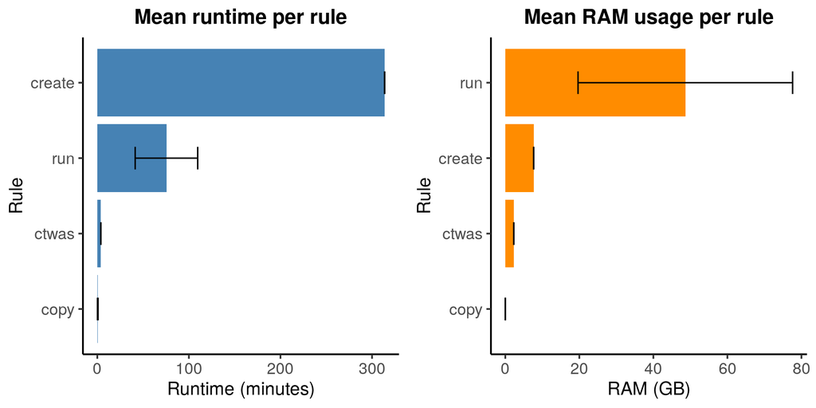